# Analyzing Loan Data - Prosper Funding LLC

# Final Plots and Summary

### Plot One - The Rates

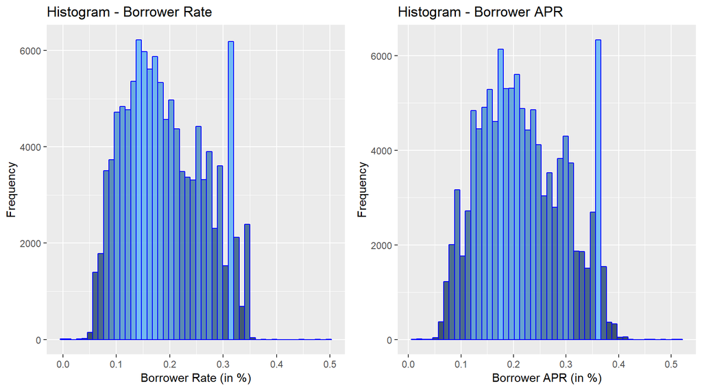

### Description One

The rates were always an interesting factor since they seemed to have ‘control’ over other features such as ProsperScore.

A little research on Prosper’s own website revealed it normal for the Borrower Rate and the Borrower APR to follow similar distributions since the APR is nothing but the Rate plus any fees charged to originate the loan.

These two plots reveal the close relationships between the two rates.

### Plot Two - The Impact of Occupation

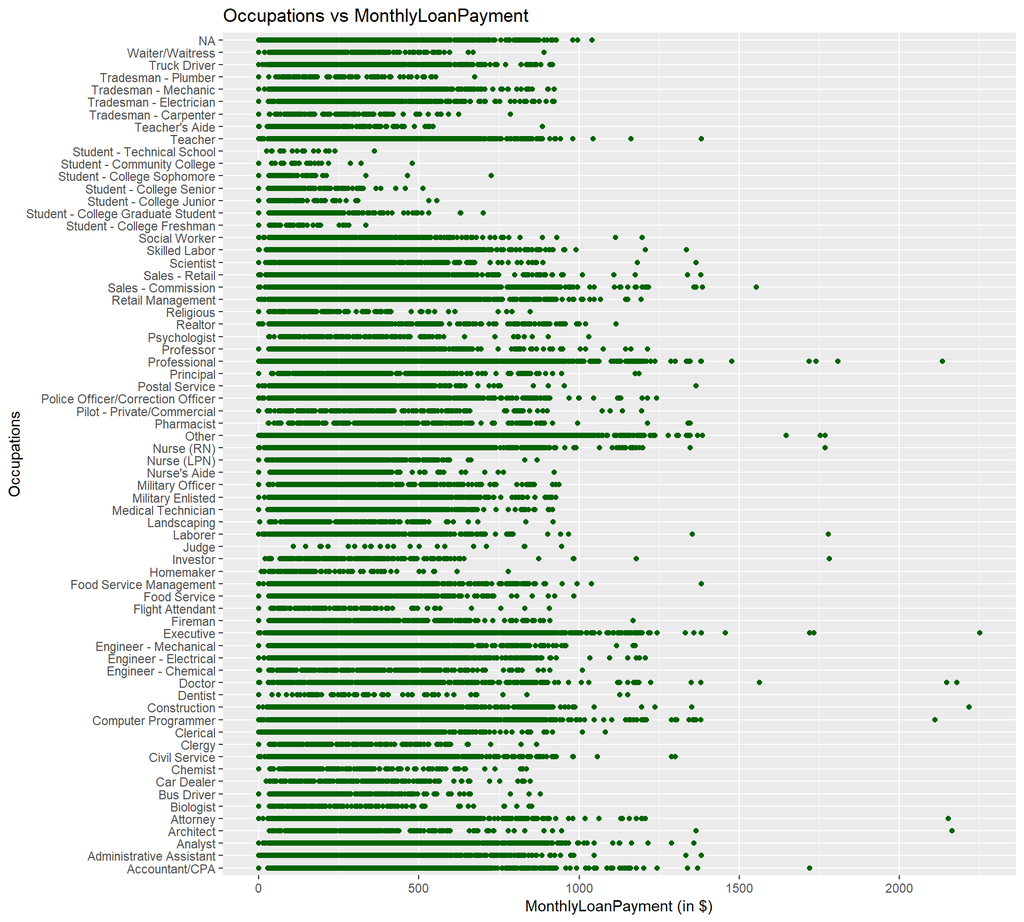

### Description Two

This plot reflects the differences in Occupations and how it affects a person’s MonthlyLoanPayment options.

We can see how certain professions make smaller payments whereas others make much larger payments and we can see a clear divide between certified professionals (e.g. Accountants) versus people who probably don’t hold a bachelor’s degree yet (e.g. Students).

### Plot Three - To Own or Not To Own

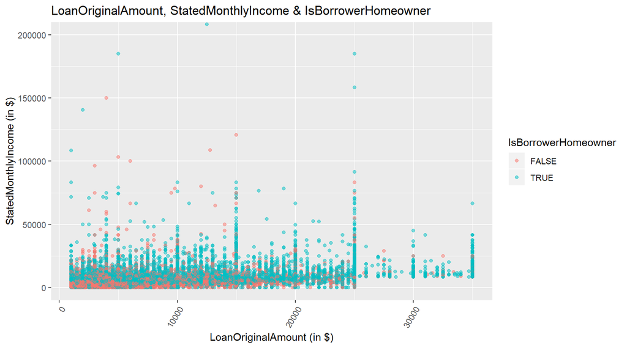

### Description Three

This final plot emphasizes the need for owning a house. House ownership seems to be a defining factor for individuals taking loans.

We can see how home ownership helps us identify monthly income and original loan amount (e.g. home owners tend to have higher monthly income and tend to take more loans, perhaps the latter being a consequence of the former).

## Reflection

As final thoughts, I can reflect upon the sheer enormousness of the dataset that I had started the investigation on - from 113937x81 to reducing that and narrowing down to 113937x12. Of these 12 key features, it was soon important to explore what role ProsperScore and LoanStatus played throughout the myriad properties/features of the dataset.

Prosper was an excellent candidate for EDA with numerous features to explore. I believe the dataset is a great option for future modeling purposes (e.g. loan default classification). Additionally, the website itself had some interesting information that helped with this analysis (e.g. APR versus Borrower Rate).

The major struggles throughout this exploration were the choice of features and particularly to not jump to conclusion after looking at only a fragment of the data. It is, indeed, important to have the bigger picture. The choices of graphs in this exercise were made keeping in mind simplicity and, therefore, there have been no fancy charts or illustrations.

In the words of John Tukey: “Exploratory data analysis can never be the whole story, but nothing else can serve as the foundation stone.”

## References

1. Prosper Website - https://www.prosper.com/
2. Prosper Help - https://prosper.zendesk.com/hc/en-us/articles/208500686-What-is-the-difference-between-Interest-Rate-and-APR-
3. Investopedia - https://www.investopedia.com/ask/answers/100314/what-difference-between-interest-rate-and-annual-percentage-rate-apr.asp
4. Special thanks to Joy Lal Chattaraj - https://github.com/Joylal4896